# Module 1 - Working with genomics data

Andrew Gentles

5/22/2018

# About this activity

This module will introduce you to loading and manipulating gene expression data. We’ll start with the PSON cell line dataset.

# Loading & inspecting data

Let’s load the data and examine it a bit. We will mostly be loading the data from an R file format called SOMETHING.Rdata. These are binary files (i.e., not human readable) that can store multiple R objects (results) that you create in the process of an R analysis. Often you will load in e.g. a matrix of information using commands like read.delim, but Rdata files are smaller and faster to load.

```r
load("../data/pson_expr_tpm_df.RData")
ls()
```

```
[1] "pson_expr_tpm_df"
```

The `names()` command tells you the names of the columns in a data frame. The ‘str’ command is one of the most useful R commands - it tells you the structure of a variable or object in R. Another useful one is “head” (and a corresponding “tail” )

```r
names(pson_expr_tpm_df)
```

```
 [1] "gene_id"  "mRNA_R17" "mRNA_R21" "mRNA_R20" "mRNA_R19" "mRNA_R18" "mRNA_R16" "mRNA_R15" "mRNA_R38" "mRNA_R42" "mRNA_R41" "mRNA_R40" "mRNA_R39" "mRNA_R37"
[15] "mRNA_R36" "mRNA_R24" "mRNA_R28" "mRNA_R27" "mRNA_R26" "mRNA_R25" "mRNA_R23" "mRNA_R22" "mRNA_R45" "mRNA_R49" "mRNA_R48" "mRNA_R47" "mRNA_R46" "mRNA_R44"
[29] "mRNA_R43" "mRNA_R10" "mRNA_R14" "mRNA_R13" "mRNA_R12" "mRNA_R11" "mRNA_R9"  "mRNA_R8"  "mRNA_R3"  "mRNA_R7"  "mRNA_R6"  "mRNA_R5"  "mRNA_R4"  "mRNA_R2"
[43] "mRNA_R1"  "mRNA_R52" "mRNA_R56" "mRNA_R55" "mRNA_R54" "mRNA_R53" "mRNA_R51" "mRNA_R50" "mRNA_R31" "mRNA_R35" "mRNA_R34" "mRNA_R33" "mRNA_R32" "mRNA_R30"
[57] "mRNA_R29" "mRNA_R59" "mRNA_R63" "mRNA_R62" "mRNA_R61" "mRNA_R60" "mRNA_R58" "mRNA_R57"
```

```r
str(pson_expr_tpm_df)
```

```
Classes ‘tbl_df’, ‘tbl’ and 'data.frame':   18682 obs. of  64 variables:
 $ gene_id : chr  "ENSG00000000003" "ENSG00000000005" "ENSG00000000419" "ENSG00000000457" ...
 $ mRNA_R17: num  33.56 0 169.46 1.85 5.73 ...
 $ mRNA_R21: num  45.1 0 129.88 1.85 11.85 ...
 $ mRNA_R20: num  39.42 0 132.06 1.77 10.16 ...
 $ mRNA_R19: num  35.61 0 113.73 1.93 9.28 ...
 $ mRNA_R18: num  32.1 0 123.4 2.3 10 ...
 $ mRNA_R16: num  39.49 0 136.29 1.54 8.93 ...
 $ mRNA_R15: num  29.9 0 137.98 2 7.47 ...
 $ mRNA_R38: num  20.8 0 185.06 1.75 7.92 ...
 $ mRNA_R42: num  19.63 0 135.75 1.41 5.5 ...
 $ mRNA_R41: num  24.6 0 173.8 1.76 8.55 ...
 $ mRNA_R40: num  12.37 0 188.45 0.84 4.33 ...
 $ mRNA_R39: num  18.25 0 173.7 1.54 5.73 ...
 $ mRNA_R37: num  21.11 0 179.63 2.35 5.16 ...
```

[output cut: 50 more lines]

Also, R has a convenient built in data viewer that displays a data frame similarly to in Excel (though you can’t manipulate things). In RStudio, you can also click on the variable under the **Environment** tab in the upper right panel. **Note:** running the chunk below will open the viewer in a new tab; you can switch back to the `module3.Rmd` tab to resume the activity.

```r
#View(pson_expr_tpm_df)
```

We can use indexing to examine the first 5 rows and 5 columns — here for the expression matrix. Note that sometimes Excel gets hold of a file at some point and mangles gene names by “correcting” genes like “*SEPT1*” to “*1-Sep*” (a date). This happens quite a bit, and you can even read a peer-reviewed article about it [here](https://genomebiology.biomedcentral.com/articles/10.1186/s13059-016-1044-7).

```r
pson_expr_tpm_df[1:5, 1:5]
```

|  | gene_id | mRNA_R17 | mRNA_R21 | mRNA_R20 | mRNA_R19 |
| --- | --- | --- | --- | --- | --- |
| 1 | ENSG00000000003 | 33.56 | 45.10 | 39.42 | 35.61 |
| 2 | ENSG00000000005 | 0.00 | 0.00 | 0.00 | 0.00 |
| 3 | ENSG00000000419 | 169.46 | 129.88 | 132.06 | 113.73 |
| 4 | ENSG00000000457 | 1.85 | 1.85 | 1.77 | 1.93 |
| 5 | ENSG00000000460 | 5.73 | 11.85 | 10.16 | 9.28 |

We saw how big the matrix was from the “str” command, but can find it another way with the `dim()`.

```r
dim(pson_expr_tpm_df)
```

```
[1] 18682    64
```

Those gene IDs are not very informative - they come from a database called ENSEMBL. More commonly, we would use the Hugo gene symbols (https://www.genenames.org/). These are the gene names you are more used to seeing (MYC, BRCA1 etc). We have this information in another file.

```r
load("../data/pson_expr_gene_info.RData")
```

Take a moment to look at the information you just downloaded. Does it have the same number of genes as the expression matrix ? In the same order ?

```r
# Find data frame name
# view data frame using one of methods above
# get size using one of methods above
```

Many things in R can work on a data frame, but often it’s easier to hae a simpler matrix

```r
pson_tpm_mat = as.matrix(pson_expr_tpm_df2[, -c(1:4)])
rownames(pson_tpm_mat) = pson_expr_tpm_df2$symbol
```

Now it’s easier to do many operations on the matrix. If you are familiar with Matlab, you’ll know that this makes speeding up computation easier, but the wheels can fall off. In R, it can digest different mixed data better. But that can be a double-edged sword because R will often produce a result even when you did something you didn’t mean.

```r
colSums(pson_tpm_mat)
```

```
mRNA_R17 mRNA_R21 mRNA_R20 mRNA_R19 mRNA_R18 mRNA_R16 mRNA_R15 mRNA_R38 mRNA_R42 mRNA_R41 mRNA_R40 mRNA_R39 mRNA_R37 mRNA_R36 mRNA_R24 mRNA_R28 mRNA_R27
925249.2 939584.8 936328.0 939342.9 937213.3 932558.1 930438.3 941026.1 934102.2 943195.8 928026.6 937107.5 935499.5 941930.0 940546.9 941475.4 945065.0
mRNA_R26 mRNA_R25 mRNA_R23 mRNA_R22 mRNA_R45 mRNA_R49 mRNA_R48 mRNA_R47 mRNA_R46 mRNA_R44 mRNA_R43 mRNA_R10 mRNA_R14 mRNA_R13 mRNA_R12 mRNA_R11  mRNA_R9
934940.7 938330.5 927800.4 939314.6 928315.2 930200.8 927158.0 929514.4 929947.4 933376.2 931928.5 950605.1 953271.7 952507.0 950621.5 934212.8 950774.9
 mRNA_R8  mRNA_R3  mRNA_R7  mRNA_R6  mRNA_R5  mRNA_R4  mRNA_R2  mRNA_R1 mRNA_R52 mRNA_R56 mRNA_R55 mRNA_R54 mRNA_R53 mRNA_R51 mRNA_R50 mRNA_R31 mRNA_R35
952000.5 936577.1 937718.2 932324.8 922843.2 935792.9 937852.1 930950.6 944337.2 945542.5 944524.4 940821.8 946705.3 941959.7 944849.8 949522.1 950227.3
mRNA_R34 mRNA_R33 mRNA_R32 mRNA_R30 mRNA_R29 mRNA_R59 mRNA_R63 mRNA_R62 mRNA_R61 mRNA_R60 mRNA_R58 mRNA_R57
951114.6 952487.6 949740.4 952105.8 946548.6 951240.0 951305.3 950446.6 951255.0 946777.2 951215.8 949333.9
```

Finally, we often take the log so that outliers don’t dominate everything. But we can’t take the log of 0 values. Therefore we often use something called the “moderated log.”"

```r
pson_tpm_mat = log2(1 + pson_tpm_mat)
```

## The physical information on these cell lines — i.e., the motility data

```r
load("../data/pson_motility_tidy_df.RData")
head(pson_motil_tidy_df)
```

| id_motil | summary_metric | average_value | standard_deviation | standard_error | total_number_of_cells_tracked | sample | id_expr | diagnosis | cellType | catalogNumber | cellLine | experimentalCondition | stiffness | stiffness_units | surface | laminate | organ | tumorType | stiffness_norm | average_value_scaled |
| --- | --- | --- | --- | --- | --- | --- | --- | --- | --- | --- | --- | --- | --- | --- | --- | --- | --- | --- | --- | --- |
| syn7576272 | end_to_end_distance_um | 4.451692 | 2.309646 | 0.4619291 | 25 | mRNA_R17 | syn11510905 | Colon Cancer | epithelial | NCI-PBCF-CCL227 | SW620 | Glass | NA | NA | Glass | NA | colon | Adenocarcinoma | NA | -0.9570433 |
| syn7576272 | speed_um_hr | 13.932440 | 4.802056 | 0.9604112 | 25 | mRNA_R17 | syn11510905 | Colon Cancer | epithelial | NCI-PBCF-CCL227 | SW620 | Glass | NA | NA | Glass | NA | colon | Adenocarcinoma | NA | -1.0397530 |
| syn7576272 | total_distance_um | 27.864880 | 9.604112 | 1.9208223 | 25 | mRNA_R17 | syn11510905 | Colon Cancer | epithelial | NCI-PBCF-CCL227 | SW620 | Glass | NA | NA | Glass | NA | colon | Adenocarcinoma | NA | -1.0397530 |
| syn7576285 | end_to_end_distance_um | 15.595602 | 25.911173 | 3.6282900 | 51 | mRNA_R21 | syn11510915 | Colon Cancer | epithelial | NCI-PBCF-CCL227 | SW620 | HyaluronicAcid Collagen | NA | NA | HyaluronicAcid | Collagen | colon | Adenocarcinoma | NA | -0.4371620 |
| syn7576285 | speed_um_hr | 18.477557 | 14.665361 | 2.0535613 | 51 | mRNA_R21 | syn11510915 | Colon Cancer | epithelial | NCI-PBCF-CCL227 | SW620 | HyaluronicAcid Collagen | NA | NA | HyaluronicAcid | Collagen | colon | Adenocarcinoma | NA | -0.8130387 |
| syn7576285 | total_distance_um | 36.955115 | 29.330722 | 4.1071225 | 51 | mRNA_R21 | syn11510915 | Colon Cancer | epithelial | NCI-PBCF-CCL227 | SW620 | HyaluronicAcid Collagen | NA | NA | HyaluronicAcid | Collagen | colon | Adenocarcinoma | NA | -0.8130387 |

Let’s try to tie gene expression to the speed that cells can move at. First pull out only that information:

```r
cell_speeds = subset(pson_motil_tidy_df, summary_metric == "speed_um_hr")
```

These were measured in different conditions:

```r
table(cell_speeds$experimentalCondition)
```

```
   30 kPa polyacrylamide Collagen 30 kPa polyacrylamide Fibronectin    500 Pa polyacrylamide Collagen 500 Pa polyacrylamide Fibronectin
                                9                                 9                                 9                                 9
                            Glass           HyaluronicAcid Collagen        HyaluronicAcid Fibronectin
                                8                                 9                                 9
```

Let’s just look at the `"HyaluronicAcid Collagen"`" condition (I picked that at random).

```r
hyal_coll = subset(cell_speeds,
                   experimentalCondition == "HyaluronicAcid Collagen")
```

We only have data for some of the cell lines for which we have gene expression data so we can just extract the gene expression for those cell lines. We need to `match()` the `sample` name in the motility information to the column names in the expression data.

```r
n = match(hyal_coll$sample, colnames(pson_tpm_mat))
pson_x = pson_tpm_mat[, n]
```

I was a bit careless there — can you see why? Hint: what if not all cell lines had expression data

Check that the rows of the motility information line up with the columns of the expression data

```r
##
```

Let’s see if any genes are correlated with the speed a cell moves at (we’re ignoring cell line type - what are we assuming?). This uses the “cor” function to produce a correlation matrix. We want to correlate “average_value” from the speed on Hyaluronic acid Collagen to the expression matrix.

```r
correls = cor(hyal_coll$average_value, t(pson_x))
```

```
the standard deviation is zero
```

There are a couple of ways we could visualize that.

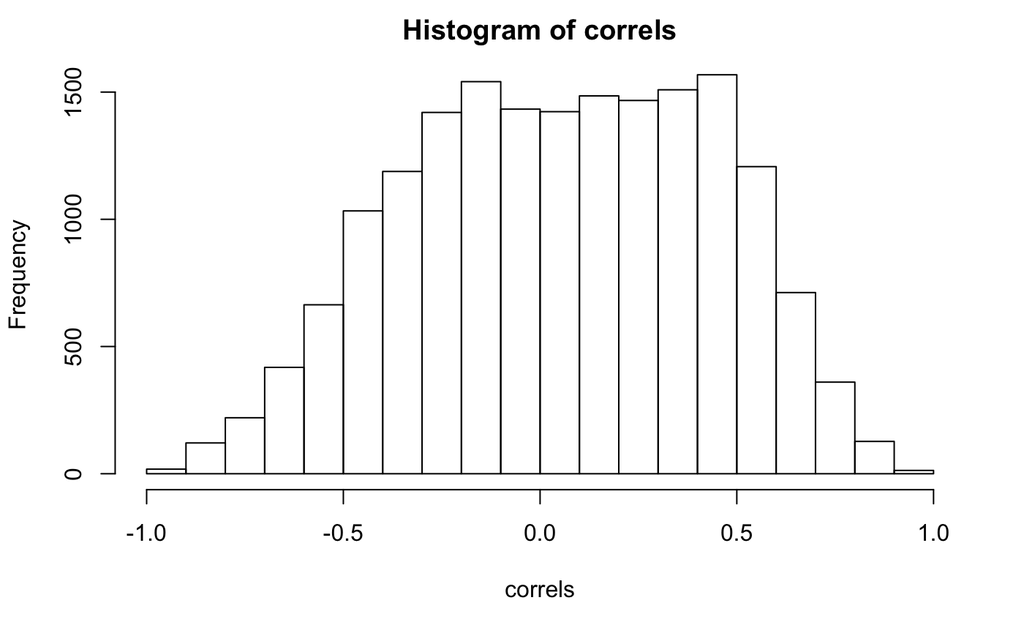

```r
#par(mfrow=c(2,1))      # This tells R I want it to layout a plot with two panels arranged as 2 rows and 1 column
hist(correls)
```

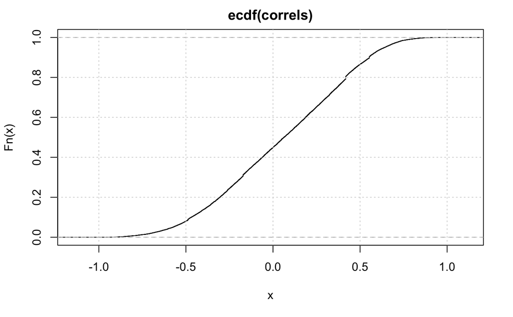

```r
plot(ecdf(correls))
grid()
```

By chance some things would be non-zero. A visual way to check this is with a quantile-quantile plot.

```r
qqnorm(correls)
qqline(correls)
```

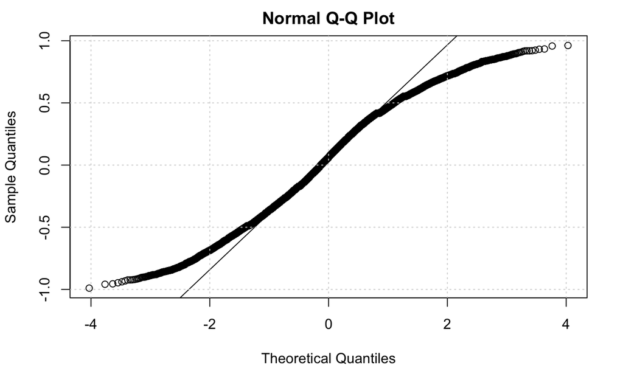

```r
grid()
```

We could also “fit” a normal distribution (Bell curve) and plot it on top of the histogram.

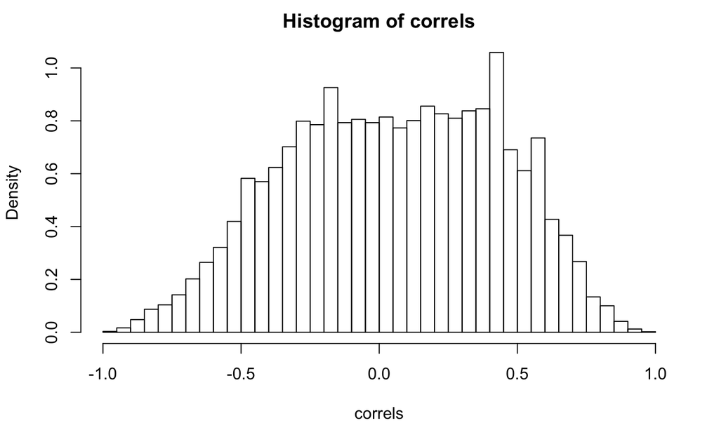

```r
m <- mean(correls)
std <- sd(correls)
hist(correls, prob = TRUE, 50)
curve(dnorm(x, mean = m, sd = std),
      col = "darkblue", lwd = 2, add = TRUE, yaxt = "n")
```

It’s a bit hard to tell from this if those are significant or not. Let’s put aside the significance for the moment and continue to look at what genes are positively or negatively correlated with cell speed. First it’s convenient to put the correlation results in a more easy to use form by flipping them on their side

```r
correltab <- data.frame(rownames(pson_x), t(correls))
```

```
some row.names duplicated: 17999,18680 --> row.names NOT used
```

```r
head(correltab)
```

|  | rownames.pson_x. | t.correls. |
| --- | --- | --- |
| 1 | TSPAN6 | 0.001783332 |
| 2 | TNMD | 0.417797531 |
| 3 | DPM1 | -0.121294991 |
| 4 | SCYL3 | 0.256023333 |
| 5 | C1orf112 | 0.275665670 |
| 6 | FGR | -0.158306068 |

```r
colnames(correltab) <- c("Gene", "Corr.to.speed")
head(correltab)
```

|  | Gene | Corr.to.speed |
| --- | --- | --- |
| 1 | TSPAN6 | 0.001783332 |
| 2 | TNMD | 0.417797531 |
| 3 | DPM1 | -0.121294991 |
| 4 | SCYL3 | 0.256023333 |
| 5 | C1orf112 | 0.275665670 |
| 6 | FGR | -0.158306068 |

And we can sort them in either direction

```r
correltab <- correltab[order(correltab$Corr.to.speed), ]
head(correltab)
```

|  | Gene | Corr.to.speed |
| --- | --- | --- |
| 8582 | ECE2 | -0.9897261 |
| 9141 | MPZL2 | -0.9586170 |
| 2522 | AHCY | -0.9551978 |
| 5104 | SLC35B1 | -0.9465020 |
| 15281 | ANO9 | -0.9389225 |
| 15231 | JAG2 | -0.9314166 |

```r
correltab <- correltab[order(correltab$Corr.to.speed, decreasing = TRUE), ]
head(correltab, 20)
```

|  | Gene | Corr.to.speed |
| --- | --- | --- |
| 16163 | GSPT2 | 0.9618930 |
| 388 | VSIG2 | 0.9575248 |
| 18047 | HLA-DPA1 | 0.9336980 |
| 9696 | ADAMTS1 | 0.9314736 |
| 10680 | EXTL2 | 0.9245984 |
| 3789 | HPS5 | 0.9199363 |
| 10922 | AIM2 | 0.9187323 |
| 2587 | SRPX | 0.9186205 |
| 17929 | HLA-DPB1 | 0.9180964 |
| 1215 | AP1M1 | 0.9142835 |

[output cut: 10 more lines]

Let’s just plot the top one vs speed to see what the relationship looks like

```r
gene <- "GSPT2"
n <- which(rownames(pson_x) == gene)
n
```

```
[1] 16163
```

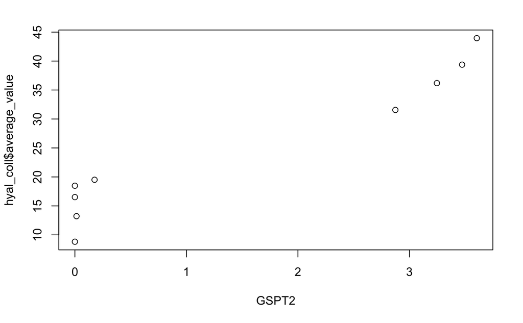

```r
plot(pson_x[n, ], hyal_coll$average_value, xlab = gene)
```

That looks a little suspicious — are different cell line types (from different types of cancer) grouping together?

```r
View(hyal_coll[order(hyal_coll$average_value), ])
```

In general we should really consider difference cancer types separately. FOr example just breast cancer. But we only have motility data on a couple of them which makes doing a rigorous analysis hard. Nonetheless, let’s see if we can get anything from the breast cancer. There are only two with motility info. One is twice as fast as the other (look at the `hyal_coll` data frame)

```r
pson_breast_tpm <- data.frame(rownames(pson_x), pson_x[,c(7,9)])
```

```
some row.names duplicated: 17999,18680 --> row.names NOT used
```

```r
names(pson_breast_tpm) <- c("Gene","Slower","Faster")
pson_breast_tpm$delta <- pson_breast_tpm[,'Faster'] - pson_breast_tpm[,'Slower']
pson_breast_tpm <- pson_breast_tpm[order(pson_breast_tpm$delta, decreasing = TRUE), ]
head(pson_breast_tpm, 20)
```

|  | Gene | Slower | Faster | delta |
| --- | --- | --- | --- | --- |
| 453 | VIM | 1.23878686 | 10.959234 | 9.720447 |
| 3921 | LDHB | 0.28688115 | 9.076067 | 8.789186 |
| 3277 | SERPINE1 | 0.01435529 | 8.718704 | 8.704349 |
| 8824 | MSN | 0.01435529 | 8.709945 | 8.695590 |
| 18079 | GPX1 | 0.04264434 | 8.720347 | 8.677703 |
| 3209 | CAV1 | 0.00000000 | 8.457955 | 8.457955 |
| 1625 | GSTP1 | 0.59454855 | 8.961392 | 8.366843 |
| 13667 | FOSL1 | 0.68706069 | 8.750841 | 8.063780 |
| 11973 | AXL | 0.18903382 | 8.201781 | 8.012747 |
| 4700 | F3 | 0.69599381 | 8.651411 | 7.955417 |

[output cut: 10 more lines]

If those were number on a lottery ticket, I’d be happy right now. Vimentin (VIM) is one of the classic genes associated with mesenchymal cells that are mobile. It is up-regulated during the epithelial-mesenchymal transition (EMT) when epithelial cells (such as those that make up a solid tissue) detach from their local environment and move.

# mini-DREAM Challenge

1. Are the speeds at which cells move on different substrates correlated ? e.g. do cell lines that move faster on glass also move faster in the “HyaluronicAcid Fibronectin” condition ? You’ll need to pull out the data for different conditions, line up the cell lines, and check the correlation
2. Try similar analysis to what we did above for the cell speed on a different medium. You could also try one of the other measures of motility such as the distance they move rather than the speed
3. Do the same thing for a different cancer type. Do similar genes come out at the top and bottom of the list as in breast cancer?
4. Go to the mSigDB website at http://software.broadinstitute.org/gsea/msigdb/annotate.jsp. Put in the top (say) 40 genes (or the bottom if you want) and compare to the gene sets that this website knows about. This is often a useful way to make sense of gene lists and put them into biological context.

## Submitting the prediction

```r
library(synapseClient)
synapseLogin(rememberMe = TRUE)
submission_filename <- paste(Sys.getenv("USER"), "activity-3.txt", sep = "_")
write.csv(prediction, submission_filename)
activity3_submission <- synStore(File(path = submission_filename, parentId = "syn10142597"))
submission <- submit(evaluation = "9604686", entity = activity3_submission)
print(submission[[1]]$id)
```

Congrats — you’ve reached the end of **Module 1**! You can now return to the **mini-DREAM Challenge** site on Synapse.